# South Sudan resilience

Trauma explore

10/14/2021

# 1 Introduction

The South Sudan Monitoring and Evaluation Support Project (MESP) is conducting a household resilience survey in 13 counties. The purpose of this household survey is to obtain baseline data in the target areas for the indicators included in the Mission’s Performance Management Plan (PMP) and the Community Roadmap, in support of USAID/South Sudan’s Strategic Framework (2020-2024).

MESP has completed data collection in six counties, and as of October 2021 is carrying out data collection in the remaining seven counties. The study team is currently reviewing the data from six counties in advance of analysis of the full set of 13 counties. This document is one of a series of documents to review various measures and indices relating to resilience.

# 2 Experience of trauma

The survey asks six questions pertaining to the incidence of trauma. The preparatory text explains that trauma occurs when distressing events cause stress that changes a person’s thinking, feelings, behavior, interpersonal relationships, physical well-being, or functioning for daily activities. The following table shows these item frequencies.

```r
trauma <- dat %>%
  select(q_711,
         q_715,
         q_719,
         q_723,
         q_727,
         q_731)

dat <- dat %>%
  mutate(trauma_thoughts = case_when(q_711 == 1 ~ 1,
                                     TRUE ~ 0),
         trauma_feelings = case_when(q_715 == 1 ~ 1,
                                     TRUE ~ 0),
         trauma_behavior = case_when(q_719 == 1 ~ 1,
                                     TRUE ~ 0),
         trauma_relations = case_when(q_723 == 1 ~ 1,
                                     TRUE ~ 0),
         trauma_physical = case_when(q_727 == 1 ~ 1,
                                     TRUE ~ 0),
         trauma_function = case_when(q_731 == 1 ~ 1,
                                     TRUE ~ 0))

trauma <- dat %>%
  select(trauma_thoughts:trauma_function)

trauma_out <- trauma %>%
  summarize(trauma_thoughts=mean(trauma_thoughts))

trauma_out <- svyrdat %>%
  group_by() %>%
  summarize(trauma_thoughts=survey_mean(trauma_thoughts),
            trauma_feelings=survey_mean(trauma_feelings),
            trauma_behavior=survey_mean(trauma_behavior),
            trauma_relations=survey_mean(trauma_relations),
            trauma_physical=survey_mean(trauma_physical),
            trauma_function=survey_mean(trauma_function)) %>%
  select(1,3,5,7,9,11) %>%
  t() %>%
  as.data.frame() %>%
  rownames_to_column("var_name") %>%
  mutate(item_num=c("q_711","q_715","q_719","q_723", "q_727","q_731"),
         Description=c("Problems with thinking",
                       "Problems with emotions",
                       "Problems with behavior",
                       "Problems with relationships",
                       "Problems with physical symptoms",
                       "Problems with physical functioning")) %>%
  select(var_name, item_num, Description, Percent=V1)

trauma_out
```

| var_name | item_num | Description | Percent |
| --- | --- | --- | --- |
| trauma_thoughts | q_711 | Problems with thinking | 0.669 |
| trauma_feelings | q_715 | Problems with emotions | 0.612 |
| trauma_behavior | q_719 | Problems with behavior | 0.55 |
| trauma_relations | q_723 | Problems with relationships | 0.576 |
| trauma_physical | q_727 | Problems with physical symptoms | 0.674 |
| trauma_function | q_731 | Problems with physical functioning | 0.478 |

A composite variable takes the value one if any of those symptoms were reported, zero otherwise. The incidence of this composite variable for exposure to trauma is 84 percent.

```r
trauma_mn <- svyrdat %>%
  group_by() %>%
  summarize(trauma=survey_mean(trauma, na.rm=T))

trauma_mn
```

| trauma | trauma_se |
| --- | --- |
| 0.84 | 0.018 |

```r
trauma_cnty <- svyrdat %>%
  group_by(county) %>%
  summarize(se = std.error(trauma),
            trauma=mean(trauma, na.rm=T)) %>%
  mutate(lower=trauma-1.96*se,
         upper=trauma+1.96*se)

trauma_cnty
```

| county | se | trauma | lower | upper |
| --- | --- | --- | --- | --- |
| Akobo | 0.0179 | 0.727 | 0.692 | 0.762 |
| Budi | 0.0194 | 0.63 | 0.592 | 0.668 |
| Duk | 0.0171 | 0.814 | 0.781 | 0.848 |
| Leer | 0.0196 | 0.61 | 0.572 | 0.649 |
| Pibor | 0.00749 | 0.968 | 0.953 | 0.982 |
| Uror | 0.0153 | 0.827 | 0.796 | 0.857 |

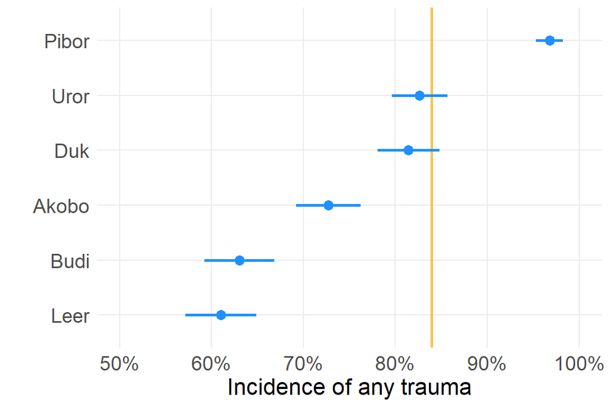

```r
ggplot(trauma_cnty, aes(trauma, fct_reorder(county, trauma))) +
  geom_vline(xintercept=trauma_mn[,1], size=1, alpha=.7, color="darkgoldenrod2") +
  #geom_vline(xintercept=4, size=1, alpha=.7, color="aquamarine3") +
  geom_point(color="dodgerblue", size=3) +
  geom_errorbar(aes(xmin=lower, xmax=upper),
                color="dodgerblue",
                width=0,
                size=1) +
  scale_x_continuous(limits=c(.5,1),
                     breaks=seq(.5,1, .1),
                     labels=percent) +
  labs(x="Incidence of any trauma",
       y="")
```

We can also look to see if there is any implicit structure in the six trauma variables, such that there may be specific types of trauma. we conduct parallel analysis to suggest any hidden structure.

### 2.0.1 Three factor model

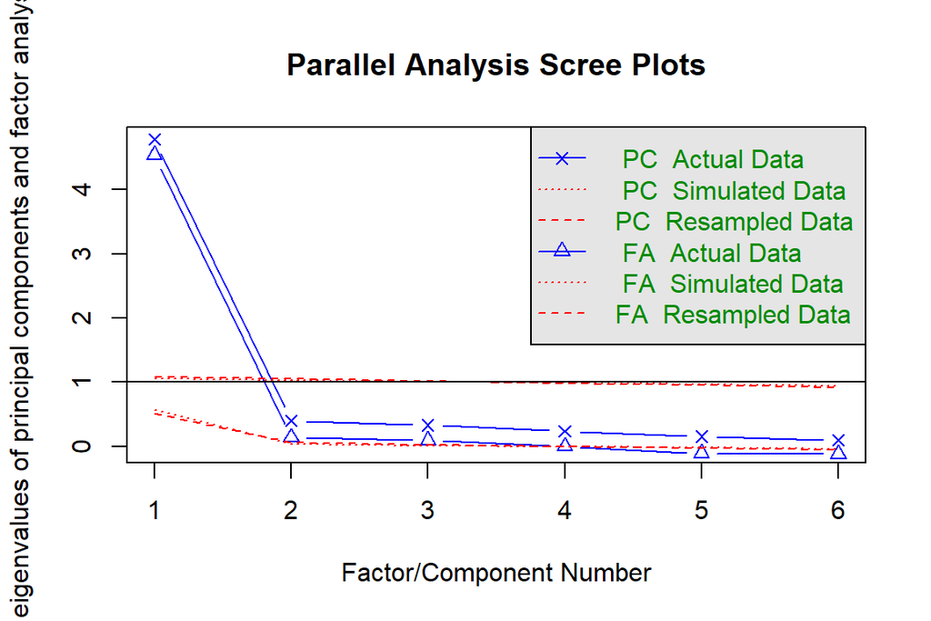

```
## Parallel analysis suggests that the number of factors =  3  and the number of components =  1
```

```r
fa.parallel(trauma,
            cor="tet")
```

One component, as many as three factors. Let’s investigate.

```r
trauma_fa_3 <- fa(trauma,
                  nfactors=3,
                  cor="tet",
                  fm="ml",
                  scores="tenBerge")
```

```r
trauma_fa_3
```

```
## Factor Analysis using method =  ml
## Call: fa(r = trauma, nfactors = 3, scores = "tenBerge", fm = "ml",
##     cor = "tet")
## Standardized loadings (pattern matrix) based upon correlation matrix
##                   ML1   ML3   ML2   h2    u2 com
## trauma_thoughts  0.28  0.44  0.24 0.76 0.237 2.4
## trauma_feelings  0.02  0.95  0.05 1.00 0.005 1.0
## trauma_behavior  0.84  0.22 -0.12 0.87 0.131 1.2
## trauma_relations 0.93 -0.09  0.11 0.90 0.102 1.0
## trauma_physical  0.03  0.07  0.93 1.00 0.005 1.0
## trauma_function  0.55  0.05  0.30 0.71 0.290 1.6
##
##                        ML1  ML3  ML2
## SS loadings           2.37 1.49 1.37
## Proportion Var        0.40 0.25 0.23
## Cumulative Var        0.40 0.64 0.87
## Proportion Explained  0.45 0.28 0.26
## Cumulative Proportion 0.45 0.74 1.00
##
##  With factor correlations of
##      ML1  ML3  ML2
## ML1 1.00 0.77 0.75
## ML3 0.77 1.00 0.64
## ML2 0.75 0.64 1.00
##
## Mean item complexity =  1.4
## Test of the hypothesis that 3 factors are sufficient.
##
## The degrees of freedom for the null model are  15  and the objective function was  6.1 with Chi Square of  21714
## The degrees of freedom for the model are 0  and the objective function was  0.05
##
## The root mean square of the residuals (RMSR) is  0.01
## The df corrected root mean square of the residuals is  NA
##
## The harmonic number of observations is  3563 with the empirical chi square  18.3  with prob <  NA
## The total number of observations was  3563  with Likelihood Chi Square =  189  with prob <  NA
##
## Tucker Lewis Index of factoring reliability =  -Inf
## Fit based upon off diagonal values = 1
## Measures of factor score adequacy
##                                                    ML1  ML3  ML2
## Correlation of (regression) scores with factors   0.97 1.00 1.00
## Multiple R square of scores with factors          0.95 0.99 0.99
## Minimum correlation of possible factor scores     0.89 0.99 0.99
```

The second factor (ML3) is built on problems with feelings and thoughts.

The third factor (ML2) is built on problems with physical symptoms.

This three-factor model captures 87 percent of the variance across the six trauma variables. Correlation between factors is high. Model goodness of fit is high.

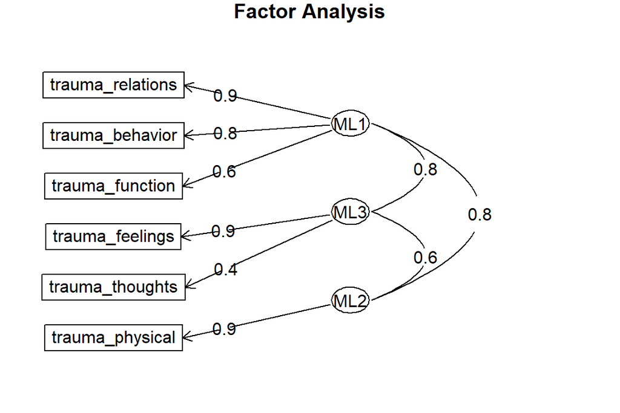

```r
fa.diagram(trauma_fa_3)
```

For purposes of using a measure of psycho-social stress to help model household resilience, we might consider ML3 (problems with thoughts and feelings) to be the factor that best captures a generalized measure of mental or emotional stress. Problems with personal relationships and behavior (ML1) may capture behavioral issues unrelated to stress from the environment, while problems with physical symptoms (ML2) may capture sickness or injury that is unrelated to stress from the environment. In the three-factor model, the ‘stress’ factor accounts for 25 percent of the variance across the six trauma items.

```r
trauma_3_stress <- trauma_fa_3$scores %>%
  as.data.frame() %>%
  select(stress=2)
describe(trauma_3_stress)
```

| vars | n | mean | sd | median | trimmed | mad | min | max | range | skew | kurtosis | se |
| --- | --- | --- | --- | --- | --- | --- | --- | --- | --- | --- | --- | --- |
| 1 | 3.56e+03 | -1.81e-16 | 1 | 0.362 | 0.0148 | 1.06 | -1.33 | 1.22 | 2.54 | -0.127 | -1.83 | 0.0168 |

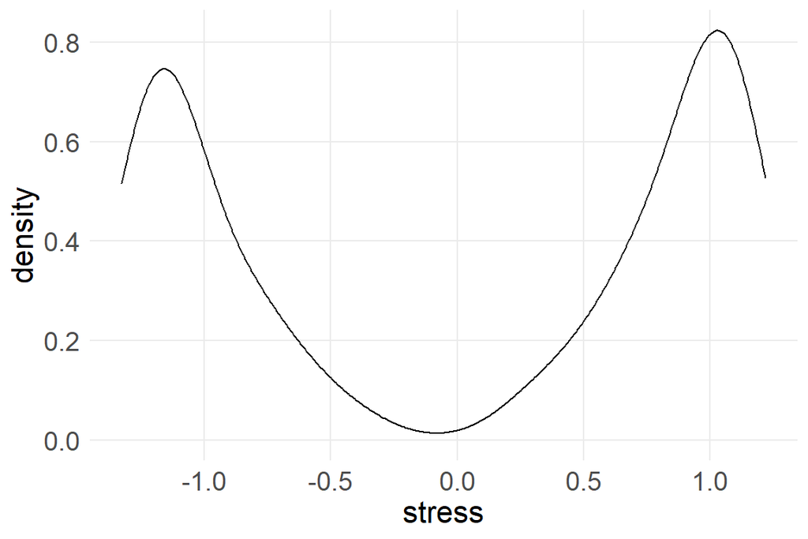

```r
ggplot(trauma_3_stress, aes(stress)) +
  geom_density()
```

Given the bimodal density of this variable, we should probably make it binary, and/or cut it by some quantile.

```r
trauma_3_stress <- trauma_3_stress %>%
  mutate(stress_bin = ifelse(stress>.8, 1,0),
         stress_quin = ntile(stress, 5))

frq(trauma_3_stress$stress_bin)
```

```
##
## x <numeric>
## # total N=3563  valid N=3563  mean=0.37  sd=0.48
##
## Value |    N | Raw % | Valid % | Cum. %
## ---------------------------------------
##     0 | 2254 | 63.26 |   63.26 |  63.26
##     1 | 1309 | 36.74 |   36.74 | 100.00
##  <NA> |    0 |  0.00 |    <NA> |   <NA>
```

```r
frq(trauma_3_stress$stress_quin)
```

```
##
## x <integer>
## # total N=3563  valid N=3563  mean=3.00  sd=1.41
##
## Value |   N | Raw % | Valid % | Cum. %
## --------------------------------------
##     1 | 713 | 20.01 |   20.01 |  20.01
##     2 | 713 | 20.01 |   20.01 |  40.02
##     3 | 713 | 20.01 |   20.01 |  60.03
##     4 | 712 | 19.98 |   19.98 |  80.02
##     5 | 712 | 19.98 |   19.98 | 100.00
##  <NA> |   0 |  0.00 |    <NA> |   <NA>
```

## 2.1 Two factor model

```r
trauma_fa_2 <- fa(trauma,
                  nfactors=2,
                  fm="ml",
                  scores="tenBerge",
                  cor="tet")
```

```r
trauma_fa_2
```

```
## Factor Analysis using method =  ml
## Call: fa(r = trauma, nfactors = 2, scores = "tenBerge", fm = "ml",
##     cor = "tet")
## Standardized loadings (pattern matrix) based upon correlation matrix
##                   ML1   ML2   h2    u2 com
## trauma_thoughts  0.47  0.45 0.76 0.242 2.0
## trauma_feelings  0.03  0.97 1.00 0.005 1.0
## trauma_behavior  0.69  0.25 0.82 0.182 1.3
## trauma_relations 1.06 -0.12 0.93 0.068 1.0
## trauma_physical  0.67  0.19 0.69 0.313 1.2
## trauma_function  0.75  0.10 0.68 0.318 1.0
##
##                        ML1  ML2
## SS loadings           3.21 1.66
## Proportion Var        0.54 0.28
## Cumulative Var        0.54 0.81
## Proportion Explained  0.66 0.34
## Cumulative Proportion 0.66 1.00
##
##  With factor correlations of
##      ML1  ML2
## ML1 1.00 0.78
## ML2 0.78 1.00
##
## Mean item complexity =  1.2
## Test of the hypothesis that 2 factors are sufficient.
##
## The degrees of freedom for the null model are  15  and the objective function was  6.1 with Chi Square of  21714
## The degrees of freedom for the model are 4  and the objective function was  0.25
##
## The root mean square of the residuals (RMSR) is  0.03
## The df corrected root mean square of the residuals is  0.06
##
## The harmonic number of observations is  3563 with the empirical chi square  114  with prob <  8e-24
## The total number of observations was  3563  with Likelihood Chi Square =  900  with prob <  1.8e-193
##
## Tucker Lewis Index of factoring reliability =  0.845
## RMSEA index =  0.251  and the 90 % confidence intervals are  0.237 0.265
## BIC =  867
## Fit based upon off diagonal values = 1
## Measures of factor score adequacy
##                                                    ML1  ML2
## Correlation of (regression) scores with factors   0.98 1.00
## Multiple R square of scores with factors          0.96 0.99
## Minimum correlation of possible factor scores     0.92 0.99
```

The first factor is built on problems with personal relationships, physical functioning, behavior, and physical symptoms.

The two-factor model captures 81 percent of the variance across the six trauma items. Correlation between factors is high. Model goodness of fit is good (TLI .845, RMSEA .25), but not great.

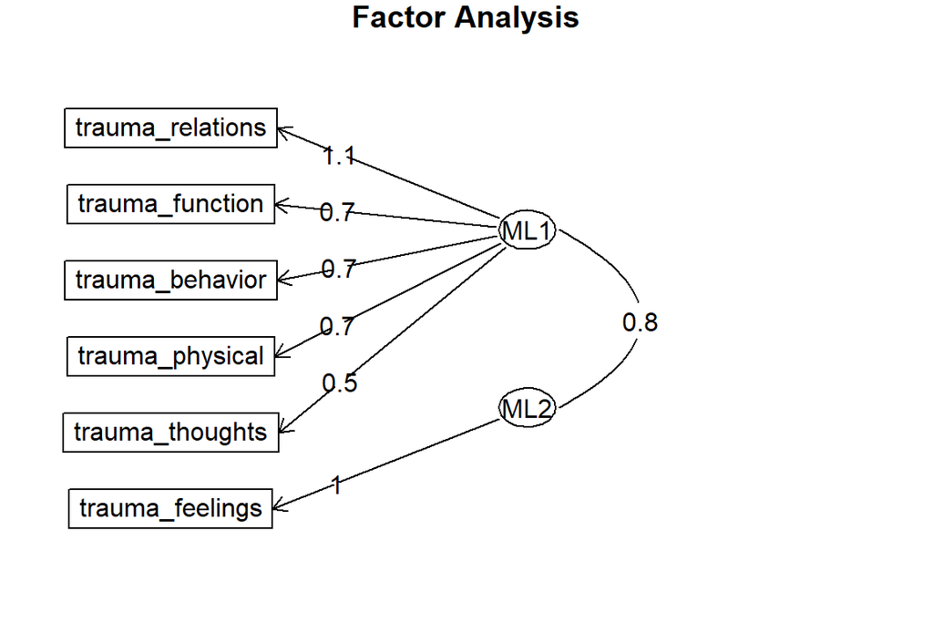

```r
fa.diagram(trauma_fa_2)
```

The two-factor model does not appear as strong as the three-factor model, but the stress factors are largely the same across the two models. Additionally, note that in the two-factor model the stress factor accounts for 28 percent of the variance across the six trauma items, while the stress factor in the three-factor model accounts for slightly less at 25 percent of the total variance.

```r
trauma_2_stress <- trauma_fa_2$scores %>%
  as.data.frame() %>%
  select(stress=2)
describe(trauma_2_stress)
```

| vars | n | mean | sd | median | trimmed | mad | min | max | range | skew | kurtosis | se |
| --- | --- | --- | --- | --- | --- | --- | --- | --- | --- | --- | --- | --- |
| 1 | 3.56e+03 | -1.58e-16 | 1 | 0.408 | 0.0153 | 1.01 | -1.4 | 1.28 | 2.68 | -0.128 | -1.81 | 0.0168 |

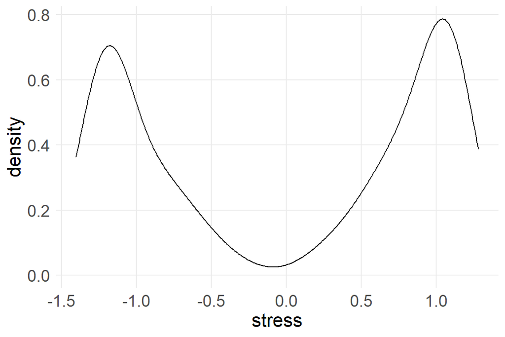

```r
ggplot(trauma_2_stress, aes(stress)) +
  geom_density()
```

Same density.

```r
trauma_2_stress <- trauma_2_stress %>%
  mutate(stress_bin = ifelse(stress>.8, 1,0),
         stress_quin = ntile(stress, 5))

frq(trauma_2_stress$stress_bin)
```

```
##
## x <numeric>
## # total N=3563  valid N=3563  mean=0.35  sd=0.48
##
## Value |    N | Raw % | Valid % | Cum. %
## ---------------------------------------
##     0 | 2306 | 64.72 |   64.72 |  64.72
##     1 | 1257 | 35.28 |   35.28 | 100.00
##  <NA> |    0 |  0.00 |    <NA> |   <NA>
```

```r
frq(trauma_2_stress$stress_quin)
```

```
##
## x <integer>
## # total N=3563  valid N=3563  mean=3.00  sd=1.41
##
## Value |   N | Raw % | Valid % | Cum. %
## --------------------------------------
##     1 | 713 | 20.01 |   20.01 |  20.01
##     2 | 713 | 20.01 |   20.01 |  40.02
##     3 | 713 | 20.01 |   20.01 |  60.03
##     4 | 712 | 19.98 |   19.98 |  80.02
##     5 | 712 | 19.98 |   19.98 | 100.00
##  <NA> |   0 |  0.00 |    <NA> |   <NA>
```

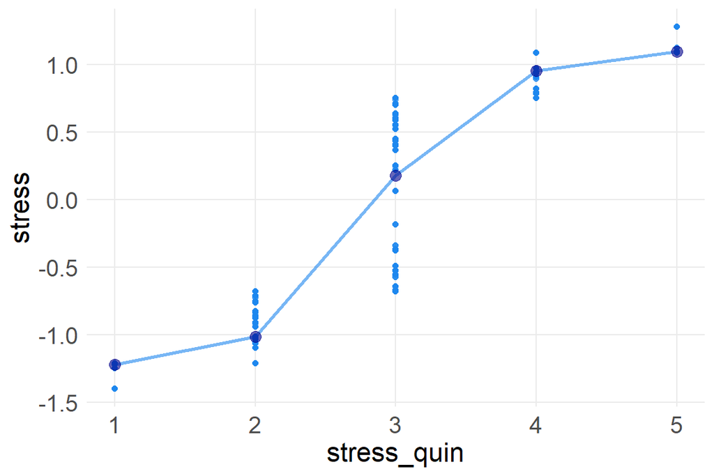

```r
ggplot(trauma_2_stress, aes(stress_quin, stress)) +
  geom_point(color="dodgerblue2", alpha=.4) +
  stat_summary(fun.y="mean", geom="line", size=1, color="dodgerblue2", alpha=.6) +
  stat_summary(fun.y="mean", geom="point", size=3, color="darkblue", alpha=.6)
```